# More Datetime Howto

Jeff Newmiller

September 9, 2018

# Desirable features for handling date/times

- Convert to and from character (format/parse)
- Compare two dates (before, same time, or after?)
- Calculate interval between two moments in time
- Create periodic sequences of moments in time
- Handle calendar/time special cases

# Cleaned Residential Data

Sample residential electric load data from London, England[^5] (pre-trimmed to one house and odd records removed)

```r
dta <- read.csv( "../data/MAC000002clean.csv", as.is = TRUE )
str(dta)
```

```
## 'data.frame':    24140 obs. of  3 variables:
##  $ LCLid   : chr  "MAC000002" "MAC000002" "MAC000002" "MAC000002" ...
##  $ DateTime: chr  "2012-10-12 00:30:00" "2012-10-12 01:00:00" "2012-10-12 01:30:00" "2012-10-12 02:00:00" ...
##  $ KWH     : num  0 0 0 0 0 0 0 0 0 0 ...
```

# Base R Timestamp

Tell R to assume timezone is Greenwich Mean Time (or Universal Time Coordinated = UTC)

```r
Sys.setenv( TZ = "GMT" ) # when you don't know how the data was coded, use GMT to get started
```

Make a `Dtm` column using base R. The “%Y-%m-%d %H:%M:%OS” format works by default, but many common formats need to be specified with a `format` argument (`?strptime`).

```r
dta_b <- dta  # make a copy so we can compare approaches later
dta_b$Dtm <- as.POSIXct( dta_b$DateTime ) # assumes TZ is set
str( dta_b$Dtm ) # confirming new column type
```

```
##  POSIXct[1:24140], format: "2012-10-12 00:30:00" "2012-10-12 01:00:00" ...
```

`POSIXct` is a time representation that borrows heavily from the *Portable Operating Systems Interface* (POSIX) standard, which uses integer values to indicate time as the number of seconds since January 1, 1970 Greenwich Mean Time. R uses a double-precision floating point number instead of an integer, but is otherwise very similar to the original standard.

# Aside: Timezones

Excel basically acts like all time is in GMT all the time… if you compute `'2012-03-26' - '2012-03-25'` in Excel you get 1 day (24 hours), even though in London, March 25, 2012 was the beginning of daylight savings time so the day was 23 hours long. For many uses this is fine, but R timestamps always keep timezones in mind so if you *want* to use simplified time in R like you can in Excel then you need to set the timezone to GMT before you do time calculations.

You can set a default timezone for time calculations in a particular R session in the manner of the previous page, or you can set an attribute `"tzone"` on each timezone variable. Timezones affect how the character strings are converted to POSIXct and back to character. It also affects how `POSIXct` <-> `POSIXlt` conversions behave.

```r
dta_b$DtmGMT <- as.POSIXct( dta_b$DateTime, tz = "GMT" )
attr( dta_b$Dtm, "tzone" )
```

```
## [1] ""
```

```r
attr( dta_b$DtmGMT, "tzone" )
```

```
## [1] "GMT"
```

It is not possible to set a separate timezone on individual `POSIXct` elements within a vector.

# Aside 2: `POSIXlt` (List or Long Time)

`POSIXlt` is the base R tool for manipulating the parts of a timestamp:

```r
Sys.setenv( TZ = "UTC" )
# see ?as.POSIXlt
dtm2 <- as.POSIXlt( c( "2016-03-13 01:00:00", "2016-03-13 03:00:00" ) )
dtm2
```

```
## [1] "2016-03-13 01:00:00 UTC" "2016-03-13 03:00:00 UTC"
```

```r
dtm2[ 1 ] < dtm2[ 2 ]
```

```
## [1] TRUE
```

```r
diff( dtm2 )
```

```
## Time difference of 2 hours
```

# Aside 2 continued: `POSIXlt` Internals

See `?DateTimeClasses`. `year` is based from 1900, `mon` represents January as 0, `wday` starts at 0 for Sunday, `yday` starts at 0 for January 1.

```r
str( unclass( dtm2 ) )
```

```
## List of 9
##  $ sec  : num [1:2] 0 0
##  $ min  : int [1:2] 0 0
##  $ hour : int [1:2] 1 3
##  $ mday : int [1:2] 13 13
##  $ mon  : int [1:2] 2 2
##  $ year : int [1:2] 116 116
##  $ wday : int [1:2] 0 0
##  $ yday : int [1:2] 72 72
##  $ isdst: int [1:2] 0 0
##  - attr(*, "tzone")= chr "UTC"
```

```r
dtm2$year + 1900
```

```
## [1] 2016 2016
```

# Date-Time Classes

These are introduced in the help page `?DateTimeClasses` and were discussed in R News 2004-4[^2]:

- `Date`
  - Cannot handle increments of less than one day
  - Internally represented as days since origin date (1970-01-01), a floating point number, fractions ignored
- `POSIXct` (Continuous Time[^1])
  - Very powerful, some people find these intimidating
  - Internally represented as seconds since origin (1970-01-01 00:00:00.000000 GMT), a floating point number, fractions allowed
  - Recommended for general use (set TZ!)
- `POSIXlt` (List Time[^2])
  - Useful for picking apart date/times
  - Internally represented as a list of nine named numeric vectors: sec, min, hour, mday, mon, year, wday, yday, isdst. Should not be used in data frames.

Note that base R does not support working with time-of-day only, since the length of a day can be different in different timezones and/or on different calendar days.

# `Date` (No Time)

```r
Sys.setenv( TZ = "UTC" )
dt1a <- as.Date( "2013-03-13" ) # see ?as.Date
dt1b <- as.Date( "3/21/2013", format="%m/%d/%Y" ) # see ?strptime
dt1b
```

```
## [1] "2013-03-21"
```

```r
as.numeric( dt1b )
```

```
## [1] 15785
```

```r
dt1a < dt1b
```

```
## [1] TRUE
```

```r
dt1b - dt1a
```

```
## Time difference of 8 days
```

# `POSIXct` (Continuous or Compact Time)

Most flexible for computing with instants of time. Can represent precision of smaller than one second, but results may be unreliable due to floating point rounding.

```r
Sys.setenv( TZ = "UTC" )
dtm1 <- as.POSIXct( c( "2016-03-13 01:00:00", "2016-03-13 03:00:00" ) )
dtm1
```

```
## [1] "2016-03-13 01:00:00 UTC" "2016-03-13 03:00:00 UTC"
```

```r
as.numeric( dtm1 )
```

```
## [1] 1457830800 1457838000
```

```r
dtm1[ 1 ] < dtm1[ 2 ]
```

```
## [1] TRUE
```

```r
diff( dtm1 )
```

```
## Time difference of 2 hours
```

# `POSIXlt` (List or Long Time)

```r
Sys.setenv( TZ = "UTC" )
# see ?as.POSIXlt
dtm2 <- as.POSIXlt( c( "2016-03-13 01:00:00", "2016-03-13 03:00:00" ) )
dtm2
```

```
## [1] "2016-03-13 01:00:00 UTC" "2016-03-13 03:00:00 UTC"
```

```r
dtm2[ 1 ] < dtm2[ 2 ]
```

```
## [1] TRUE
```

```r
diff( dtm2 )
```

```
## Time difference of 2 hours
```

# `POSIXlt` Internals

See `?DateTimeClasses`. `year` is based from 1900, `mon` represents January as 0, `wday` starts at 0 for Sunday, `yday` starts at 0 for January 1.

```r
str( unclass( dtm2 ) )
```

```
## List of 9
##  $ sec  : num [1:2] 0 0
##  $ min  : int [1:2] 0 0
##  $ hour : int [1:2] 1 3
##  $ mday : int [1:2] 13 13
##  $ mon  : int [1:2] 2 2
##  $ year : int [1:2] 116 116
##  $ wday : int [1:2] 0 0
##  $ yday : int [1:2] 72 72
##  $ isdst: int [1:2] 0 0
##  - attr(*, "tzone")= chr "UTC"
```

```r
dtm2$year + 1900
```

```
## [1] 2016 2016
```

# `difftime` for Durations

The amount of time between two points in time is treated differently than the points in time themselves. You cannot add two `POSIXct` values, but you can add a `POSIXct` with as many `difftime` values as desired.

```r
diftm1 <- as.difftime( 30, units="mins" ) # see ?as.difftime
dtm1[ 1 ] + diftm1
```

```
## [1] "2016-03-13 01:30:00 UTC"
```

```r
dtm1[ 1 ] + as.difftime( 2, units="weeks" )
```

```
## [1] "2016-03-27 01:00:00 UTC"
```

# `difftime` Numeric Equivalent

If you need to know the value of a difftime you must remember to specify the units or you may get whatever “convenient” units R wants to use:

```r
as.numeric( diftm1 ) # not recommended
```

```
## [1] 30
```

```r
as.numeric( diftm1, units="mins" )
```

```
## [1] 30
```

```r
as.numeric( diftm1, units="secs" )
```

```
## [1] 1800
```

# Timezones (1)

```r
on <- OlsonNames()
tail( on ) # a few examples
```

```
## [1] "US/Pacific-New" "US/Samoa"       "UTC"            "W-SU"
## [5] "WET"            "Zulu"
```

```r
grep( "Los_Angeles", on, value=TRUE )
```

```
## [1] "America/Los_Angeles"
```

Note that even though sometimes R will use a 3-letter timezone abbreviation, such shorthand is usually not acceptable for *specifying* the timezone.

# Timezones (2)

No matter what timezone you use, the underlying numeric value of a `POSIXct` will be assumed to count from the origin instant in GMT.

If you don’t have any reason to be concerned with timezones in your data, you can make life “easy” for yourself by setting your working timezone to be “GMT” or “UTC”.

Converting `Date` to `POSIXct` *always* treats the date as beginning of the day in GMT, so if you use any other timezone for other values then you will want to “force” the timezone to be compatible with any other `POSIXct` values you may be working with.

Note that each vector of `POSIXct` can have its own timezone, but some functions can cause that timezone to get lost, or will create time values internally using the default (TZ) timezone, so it is simplest to change the TZ as needed while doing input, then use some single timezone of your choosing while doing calculations and generating output.

# `lubridate` package (1)

The `lubridate`[^3] package provides many “helper” functions for working with `POSIXct` and `Date` values.

```r
library(lubridate)
mdy( "3/14/2013" ) == as.Date( "3/14/2013", format="%m/%d/%Y" )
```

```
## [1] TRUE
```

```r
dmy_hms( "14/3/13 1:15:45" ) == as.POSIXct( "14/3/13 1:15:45", format = "%d/%m/%y %H:%M:%S")
```

```
## [1] TRUE
```

# `lubridate` package (2)

You can repair a time value that was converted to POSIXct with the wrong timezone:

```r
dtm1[ 1 ]
```

```
## [1] "2016-03-13 01:00:00 UTC"
```

```r
force_tz( dtm1, "US/Pacific" ) # this is a different point in time
```

```
## [1] "2016-03-13 01:00:00 PST" "2016-03-13 03:00:00 PDT"
```

Or you can display a given instant of time using a different timezone:

```r
with_tz( dtm1, "US/Pacific" )
```

```
## [1] "2016-03-12 17:00:00 PST" "2016-03-12 19:00:00 PST"
```

```r
# which is easier to remember than
# attr( dtm1, "tzone" ) <- "US/Pacific"
```

# `lubridate` package (3)

Three additional ways beyond `difftime` to represent time intervals are also provided:

```r
interval( dtm1[ 1 ], dtm1[ 2 ] ) # a very specific interval of time
```

```
## [1] 2016-03-13 01:00:00 UTC--2016-03-13 03:00:00 UTC
```

```r
dtm1PT <- force_tz( dtm1[ 1 ], "US/Pacific" )
dtm1PT + days( 1 ) # add a 1 day period (acts like a calendar)
```

```
## [1] "2016-03-14 01:00:00 PDT"
```

```r
dtm1PT + ddays( 1 ) # add a 1 day duration (much like difftime(1,units="days"))
```

```
## [1] "2016-03-14 02:00:00 PDT"
```

There exists a cheat sheet summary of `lubridate` functions.[^4]

# Other approaches to handling time

Some people think the `POSIXt` approach is too rigid, and try out their own ideas for handling time:

- `chron::chron`
  - Contributed package, behaves similar to Excel
  - Internally represented as days since origin date (1970-01-01), a floating point number, including the fractional part!
- `zoo::yrmon`
  - Cannot handle increments of less than one month
  - Internally represented as numeric years, a floating point number, always rounded to nearest 1/12 when displayed

# Detour: Floating Point Error

R FAQ 7.31[^5] warns against depending on exact results when using floating point fractions:

```r
x <- 0.3     # floating point is always approximate
0.6 == 2 * x # works
```

```
## [1] TRUE
```

```r
0.9 == 3 * x # but you cannot rely on it
```

```
## [1] FALSE
```

# Detour: Floating Point Error

Why not equal?

```r
0.9 - 3 * x
```

```
## [1] 1.110223e-16
```

Error in `0.3` has become three times larger, but error in `0.9` is about the same as it was in `0.3`.

This imprecision is not unique to R… this applies to all software that uses floating point numbers.

# Detour: Floating Point Error

It is best to use a date/time representation that uses non-fractional values for your application…

- `Date` if you never use time-of-day, or
- `POSIXct` if your smallest precision is one second.

If your smallest precision is less than one second, `POSIXt` may introduce rounding errors so it is best to minimize the amount of calculations performed with such timestamps.

# `chron`

- Very similar to Excel time (simple)

```r
library(chron)
dtm1 <- chron( dates. = c( "3/13/2016", "3/13/2016" )
             , times. = c( "01:00:00", "03:00:00" )
             )
dtm1  # automatically formatted for display
```

```
## [1] (03/13/16 01:00:00) (03/13/16 03:00:00)
```

# `chron` Internal Representation

See what R is storing without the automatic formatting:

```r
unclass( dtm1 )
```

```
## [1] 16873.04 16873.12
## attr(,"format")
##   dates   times
## "m/d/y" "h:m:s"
## attr(,"origin")
## month   day  year
##     1     1  1970
```

# `chron` Comparison

```r
dtm1[ 1 ] < dtm1[ 2 ]
```

```
## [1] TRUE
```

```r
diff( dtm1 )
```

```
## [1] 02:00:00
```

# `chron` Spring Forward

- Does not understand timezones
- Plotting
  - base graphics doesn’t display right
  - ggplot automatically converts to POSIXct in `GMT` timezone (To display right, set `TZ="GMT"` when working with `chron`)

```r
library(ggplot2)
dtms1 <- seq( dtm1[ 1 ], dtm1[ 2 ], times( "00:30:00" ) ); dtms1
```

```
## [1] (03/13/16 01:00:00) (03/13/16 01:30:00) (03/13/16 02:00:00)
## [4] (03/13/16 02:30:00) (03/13/16 03:00:00)
```

# `chron` Spring Forward

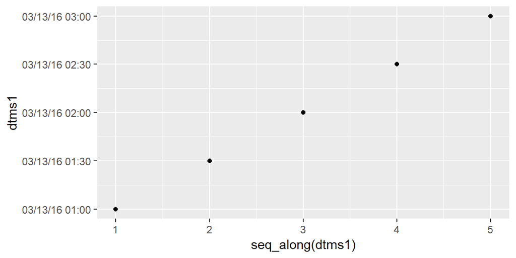

```r
Sys.setenv( TZ = "GMT" )
qplot( seq_along( dtms1 ), dtms1 ) +
  chron::scale_y_chron( format="%m/%d/%y %H:%M" )
```

# `chron` Sequence Rounding

```r
dtm2a <- chron( "02/20/13", "00:00:00" )
dtm2b <- chron( "07/03/18", "15:30:00" ) # stop at 3:30pm
dtm2 <- seq( from=dtm2a, to=dtm2b, by=times( "00:15:00" ) )
tail( dtm2 ) # stops one value too soon
```

```
## [1] (07/03/18 14:00:00) (07/03/18 14:15:00) (07/03/18 14:30:00)
## [4] (07/03/18 14:45:00) (07/03/18 15:00:00) (07/03/18 15:15:00)
```

```r
length( dtm2 )
```

```
## [1] 188126
```

# `POSIXct` Sequence Rounding

```r
Sys.setenv( TZ="GMT" ) # emulate chron behavior
dtm3a <- as.POSIXct( "02/20/13 00:00:00"
                   , format = "%m/%d/%y %H:%M:%S"
                   )
dtm3b <- as.POSIXct( "07/03/18 15:30:00"
                   , format = "%m/%d/%y %H:%M:%S"
                   )
dtm3 <- seq( from = dtm3a
           , to = dtm3b
           , by = as.difftime( 15, units="mins" )
           )
tail( dtm3 )   # does include final value
```

```
## [1] "2018-07-03 14:15:00 GMT" "2018-07-03 14:30:00 GMT"
## [3] "2018-07-03 14:45:00 GMT" "2018-07-03 15:00:00 GMT"
## [5] "2018-07-03 15:15:00 GMT" "2018-07-03 15:30:00 GMT"
```

```r
length( dtm3 ) # one more than cron example
```

```
## [1] 188127
```

# `zoo` Package offers `yearmon`/`yrqtr` alternatives

- Intended for long series of monthly data (e.g. financial data)

```r
library(zoo)
dt1 <- as.yearmon( c( "2016-03", "2016-04" ) )
dt1  # automatically formatted for display
```

```
## [1] "Mar 2016" "Apr 2016"
```

# `zoo` Internal Representation

See what R is storing without the automatic formatting:

```r
unclass( dt1 )
```

```
## [1] 2016.167 2016.250
```

# `zoo` Comparison

```r
dt1[ 1 ] < dt1[ 2 ]
```

```
## [1] TRUE
```

```r
diff( dt1 ) # displayed nonsensically
```

```
## [1] "Feb 0000"
```

# `zoo` Sequences

Typical to build floating point sequences, then convert to `yearmon` type:

```r
n <- 1416
f2a <- seq( 1900
          , 1900 + n/12
          , by = 1/12 # unsafe practice
          )
d2a <- as.yearmon( f2a ) # rounded when converted
tail( d2a ) #  internal round-to-month is very robust
```

```
## [1] "Aug 2017" "Sep 2017" "Oct 2017" "Nov 2017" "Dec 2017" "Jan 2018"
```

```r
f2b <- 1900 + seq( 0, n )/12 # safer way to handle fractions
d2b <- as.yearmon( f2b )
tail( d2b ) # no difference
```

```
## [1] "Aug 2017" "Sep 2017" "Oct 2017" "Nov 2017" "Dec 2017" "Jan 2018"
```

```r
as.numeric( f2a[ length( f2a ) ] ) - as.numeric( f2b[ length( f2b ) ] )
```

```
## [1] 0
```

[^1]: https://cran.r-project.org/doc/FAQ/R-FAQ.html#Why-doesn_0027t-R-think-these-numbers-are-equal_003f
[^2]: https://cran.r-project.org/doc/FAQ/R-FAQ.html#Why-doesn_0027t-R-think-these-numbers-are-equal_003f
[^3]: G. Grolemund and H. Wickham, “Dates and Times Made Easy with lubridate,” Journal of Statistical Software, vol. 40, no. 3, pp. 1–25, 2011 [Online]. Available: http://www.jstatsoft.org/v40/i03/
[^4]: “Dates and times with lubridate :: CHEAT SHEET.” RStudio, Dec-2017 [Online]. Available: https://github.com/rstudio/cheatsheets/raw/master/lubridate.pdf
[^5]: https://cran.r-project.org/doc/FAQ/R-FAQ.html#Why-doesn_0027t-R-think-these-numbers-are-equal_003f